# PE7049 - Big Data & Cloud Computing - Final Assessment

### SARIMA Model

```python
# Use grid search to find optimal parameters for SARIMA model
p = d = q = range(0, 2)
seasonal_period = 12
pdq = list(itertools.product(p, d, q))
seasonal_pdq = [(x[0], x[1], x[2],seasonal_period) for x in list(itertools.product(p, d, q))]

for param in pdq:
    for param_seasonal in seasonal_pdq:
        try:
            mod =\
            sm.tsa.statespace.SARIMAX(train,
                                      order=param,
                                      seasonal_order=param_seasonal,
                                      enforce_invertibility=False,
                                     enforce_stationarity=False)
            results = mod.fit()
            print('ARIMA{}x{} - AIC:{}'.format(param, param_seasonal, results.aic))
        except Exception as ex:
            print(ex)
            continue
```

```
ARIMA(0, 0, 0)x(0, 0, 0, 12) - AIC:2037.5699911282497
ARIMA(0, 0, 0)x(0, 0, 1, 12) - AIC:47045.30690620079
ARIMA(0, 0, 0)x(0, 1, 0, 12) - AIC:1496.6016136850058
ARIMA(0, 0, 0)x(0, 1, 1, 12) - AIC:1236.460264791392
ARIMA(0, 0, 0)x(1, 0, 0, 12) - AIC:1450.3841909769164
ARIMA(0, 0, 0)x(1, 0, 1, 12) - AIC:1408.3180355427946
ARIMA(0, 0, 0)x(1, 1, 0, 12) - AIC:1195.1822316918397
ARIMA(0, 0, 0)x(1, 1, 1, 12) - AIC:1167.0237029104787
ARIMA(0, 0, 1)x(0, 0, 0, 12) - AIC:1959.5118482155656
ARIMA(0, 0, 1)x(0, 0, 1, 12) - AIC:47159.07648157446
ARIMA(0, 0, 1)x(0, 1, 0, 12) - AIC:1419.052654095
ARIMA(0, 0, 1)x(0, 1, 1, 12) - AIC:1178.010625239591
ARIMA(0, 0, 1)x(1, 0, 0, 12) - AIC:1793.6457961989713
ARIMA(0, 0, 1)x(1, 0, 1, 12) - AIC:1725.7012741374415
ARIMA(0, 0, 1)x(1, 1, 0, 12) - AIC:1215.6993029482112
ARIMA(0, 0, 1)x(1, 1, 1, 12) - AIC:1169.8389018684732
ARIMA(0, 1, 0)x(0, 0, 0, 12) - AIC:1584.9552702473716
ARIMA(0, 1, 0)x(0, 0, 1, 12) - AIC:1325.5106167516967
ARIMA(0, 1, 0)x(0, 1, 0, 12) - AIC:1283.7183975132705
ARIMA(0, 1, 0)x(0, 1, 1, 12) - AIC:1051.1214785061159
ARIMA(0, 1, 0)x(1, 0, 0, 12) - AIC:1304.1811611912356
ARIMA(0, 1, 0)x(1, 0, 1, 12) - AIC:1279.4075292405034
ARIMA(0, 1, 0)x(1, 1, 0, 12) - AIC:1063.573131144983
ARIMA(0, 1, 0)x(1, 1, 1, 12) - AIC:1046.207911900734
ARIMA(0, 1, 1)x(0, 0, 0, 12) - AIC:1558.4477572619162
ARIMA(0, 1, 1)x(0, 0, 1, 12) - AIC:1303.3474678017508
ARIMA(0, 1, 1)x(0, 1, 0, 12) - AIC:1257.863231090443
ARIMA(0, 1, 1)x(0, 1, 1, 12) - AIC:1027.364620958915
ARIMA(0, 1, 1)x(1, 0, 0, 12) - AIC:1304.028031192204
ARIMA(0, 1, 1)x(1, 0, 1, 12) - AIC:1253.9484389308589
ARIMA(0, 1, 1)x(1, 1, 0, 12) - AIC:1064.6867692749001
ARIMA(0, 1, 1)x(1, 1, 1, 12) - AIC:1026.0848737118088
ARIMA(1, 0, 0)x(0, 0, 0, 12) - AIC:1604.1175705334974
ARIMA(1, 0, 0)x(0, 0, 1, 12) - AIC:1376.5901716936212
ARIMA(1, 0, 0)x(0, 1, 0, 12) - AIC:1304.124093752397
ARIMA(1, 0, 0)x(0, 1, 1, 12) - AIC:1069.3498399327227
ARIMA(1, 0, 0)x(1, 0, 0, 12) - AIC:1326.1780263026665
ARIMA(1, 0, 0)x(1, 0, 1, 12) - AIC:1326.4778022445364
ARIMA(1, 0, 0)x(1, 1, 0, 12) - AIC:1066.446871239327
ARIMA(1, 0, 0)x(1, 1, 1, 12) - AIC:1067.2874400194382
```

[output cut: 9 more lines]

```
ARIMA(1, 1, 0)x(0, 0, 1, 12) - AIC:1317.742491300723
ARIMA(1, 1, 0)x(0, 1, 0, 12) - AIC:1278.184367732208
ARIMA(1, 1, 0)x(0, 1, 1, 12) - AIC:1047.0709790700698
ARIMA(1, 1, 0)x(1, 0, 0, 12) - AIC:1280.077211213821
ARIMA(1, 1, 0)x(1, 0, 1, 12) - AIC:1274.7580399381409
ARIMA(1, 1, 0)x(1, 1, 0, 12) - AIC:1043.9330514038381
ARIMA(1, 1, 0)x(1, 1, 1, 12) - AIC:1045.50532570833
ARIMA(1, 1, 1)x(0, 0, 0, 12) - AIC:1555.1881096699015
ARIMA(1, 1, 1)x(0, 0, 1, 12) - AIC:1302.681636117485
ARIMA(1, 1, 1)x(0, 1, 0, 12) - AIC:1259.5345406478777
ARIMA(1, 1, 1)x(0, 1, 1, 12) - AIC:1029.3416122832728
ARIMA(1, 1, 1)x(1, 0, 0, 12) - AIC:1281.960402955018
ARIMA(1, 1, 1)x(1, 0, 1, 12) - AIC:1255.8815910995893
ARIMA(1, 1, 1)x(1, 1, 0, 12) - AIC:1045.447633048496
ARIMA(1, 1, 1)x(1, 1, 1, 12) - AIC:1028.0218722471982
```

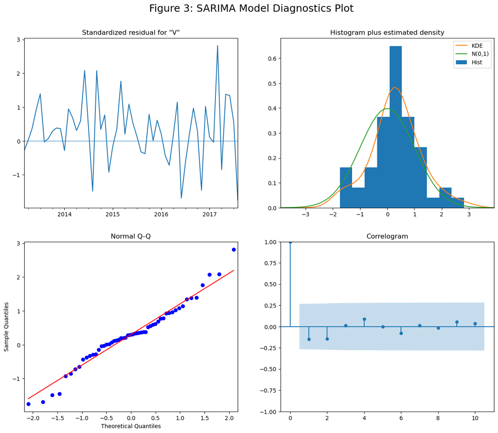

```python
# The lowest AIC in the previous step was 1026.0848737118088, so fit the model with
# the following parameters - ARIMA(0, 1, 1)x(1, 1, 1, 12).
order = (0, 1, 1)
seasonal_order = (1, 1, 1, 12)
sar_model = sm.tsa.statespace.SARIMAX(train,
                            order=order,
                            seasonal_order=seasonal_order,
                            enforce_invertibility=False,
                            enforce_stationarity=False)
sar_result = sar_model.fit()

# Plot the model diagnostics to check whether it is a good fit.
sar_result.plot_diagnostics(figsize=(15, 12))

plt.suptitle('Figure 3: SARIMA Model Diagnostics Plot', fontsize=18, y=0.95)
plt.show()
```

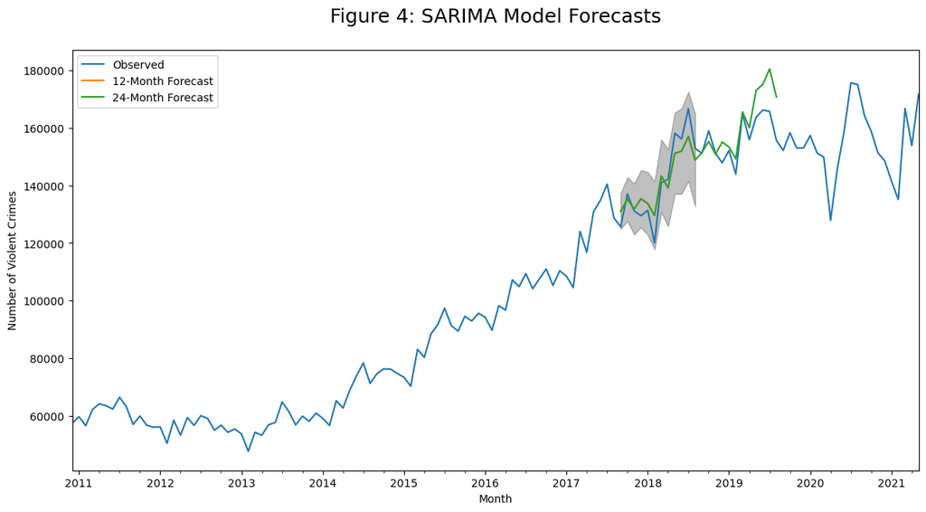

```python
# Get forecast and confidence intervals for 12 months ahead
sar_forecast = sar_result.get_forecast(steps=12)
sar_forecast_values = sar_forecast.predicted_mean
confidence_intervals = sar_forecast.conf_int()

# Also get forecast for 24 months ahead for analytical purposes
sar_forecast24 = sar_result.get_forecast(steps=24)
sar_forecast_values24 = sar_forecast24.predicted_mean

# Plot forecast
ax = claim1_pdf['Violent_Crimes'].plot(figsize=(14, 7), label='Observed')
sar_forecast_values.plot(ax=ax, label='12-Month Forecast')
sar_forecast_values24.plot(ax=ax, label='24-Month Forecast')
ax.fill_between(confidence_intervals.index,
                confidence_intervals.iloc[:, 0],
                confidence_intervals.iloc[:, 1], color='k', alpha=.25)
ax.set_xlabel('Month')
ax.set_ylabel('Number of Violent Crimes')
ax.set_title('Figure 4: SARIMA Model Forecasts', fontsize=18, y=1.05)

plt.legend()
plt.show()
```

### Holt-Winters Exponential Smoothing (HWES) Model

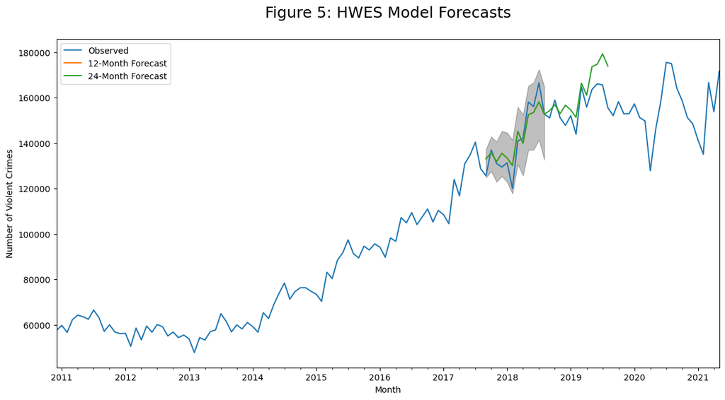

```python
# Create HWES Model and fit it
hwes_model = HWES(train, seasonal_periods=12, trend='add', seasonal='add')
hwes_result = hwes_model.fit()

# Get forecast and confidence intervals for 12 and 24 months ahead, then plot
hwes_forecast = hwes_result.forecast(steps=12)
hwes_forecast24 = hwes_result.forecast(steps=24)
ax = claim1_pdf['Violent_Crimes'].plot(label='Observed', figsize=(14, 7))
hwes_forecast.plot(ax=ax, label='12-Month Forecast')
hwes_forecast24.plot(ax=ax, label='24-Month Forecast')
ax.fill_between(confidence_intervals.index,
                confidence_intervals.iloc[:, 0],
                confidence_intervals.iloc[:, 1], color='k', alpha=.25)

ax.set_xlabel('Month')
ax.set_ylabel('Number of Violent Crimes')
ax.set_title('Figure 5: HWES Model Forecasts', fontsize=18, y=1.05)

plt.legend()
plt.show()
```

### Compare SARIMA & HWES Models

```python
### SARIMA Model MAE, RMSE & MAPE Calculations

# Predicted values and actual values
sar_predicted_values = sar_forecast_values.values
sar_actual_values = test.values.flatten()

# Mean Absolute Error (MAE)
sar_mae = np.mean(np.abs(sar_predicted_values - sar_actual_values))

# Root Mean Squared Error (RMSE)
sar_mse = np.mean((sar_predicted_values - sar_actual_values) ** 2)
sar_rmse = np.sqrt(sar_mse)

# Mean Absolute Percentage Error (MAPE)
sar_mape = np.mean(np.abs((sar_predicted_values - sar_actual_values) / sar_actual_values)) * 100


### HWES Model MAE, RMSE & MAPE Calculations

# Predicted values and actual values
hwes_predicted_values = hwes_forecast.values
hwes_actual_values = test.values.flatten()

# Mean Absolute Error (MAE)
hwes_mae = np.mean(np.abs(hwes_predicted_values - hwes_actual_values))

# Root Mean Squared Error (RMSE)
hwes_mse = np.mean((hwes_predicted_values - hwes_actual_values) ** 2)
hwes_rmse = np.sqrt(hwes_mse)

# Mean Absolute Percentage Error (MAPE)
hwes_mape = np.mean(np.abs((hwes_predicted_values - hwes_actual_values) / hwes_actual_values)) * 100


### Summarise the figures in a dataframe to ease comparison
x = [['SARIMA', sar_mae, sar_rmse, sar_mape], ['HWES', hwes_mae, hwes_rmse, hwes_mape]]
df = pd.DataFrame(x, columns=['Model', 'MAE', 'RMSE', 'MAPE'])
df
```

|  | Model | MAE | RMSE | MAPE |
| --- | --- | --- | --- | --- |
| 0 | SARIMA | 4647.973161 | 5415.029396 | 3.304250 |
| 1 | HWES | 4221.425428 | 5248.278656 | 3.069085 |

Figure 1 shows violent crimes rising steadily from the beginning of 2014 to around the time the claim was made. The decomposition plot in figure 2 confirms the presence of the trend, as well as an annual seasonal component. Consequently, the decision to use SARIMA and HWES models to forecast the time series is sound.

It is clear the time series is not stationary, as all three critical values of the ADF test are lower than the test statistic. Two rounds of differencing were able to achieve stationarity, therefore the SARIMA model was left to find the optimum value of *d*.

The diagnostics plot in figure 3 indicates the SARIMA model fits the data quite well. The distribution in the histogram is not far from being normal, most points in the QQ plot cluster on or around the straight line, and all of the lags in the correlogram are contained within the confidence band. Furthermore, the standardized residual appears to be close to the ideal value of zero [11].

Each model performs well over 12 months, but which one is better? It is hard to answer this question solely using visualisations, therefore it is useful to compare some metrics to inform the analysis. Numerous metrics are utilised in the field of time series forecasting because there is no consensus which is best and none captures all the characteristics of a forecast [19]. Here, the MAE, RMSE and MAPE were used to compare the models and the value of each measure for the 12-month forecast is shown in the table above.

The HWES model has lower scores for each measure than SARIMA and therefore performs better in this instance. It's MAE is 4221, which is the average value of the error between the predicted number of violent crimes and the observed number [20]. The RMSE assigns more weight to large errors [21] and in this case is 5248, which indicates there aren't too many sizeable errors as the value is relatively close to the MAE. In isolation, the MAE and RMSE don't quantify the error in relation to the size of the actual values, unlike the MAPE [22]. Again, a lower figure is better and the MAPE of the HWES model is 3.1%, which is very low.

## 5. Claims 2 and 3 - Data Extraction and Filtering

```python
# These claims will be analysed using the raw data from the farms_df and crime_df dataframes.
# Check the date range of both dfs. Only use during development and comment out when processing big data.

#fa_start = f.min('FQ Start').alias('Start')
#fa_end = f.max('FQ Start').alias('End')
#fa_dates = farms_df.select(fa_start, fa_end)
#print("Date Range of Firearms Offences")
#fa_dates.show()

#c_start = f.min('Month').alias('Start')
#c_end = f.max('Month').alias('End')
#c_dates = crime_df.select(c_start, c_end)
#print("Date Range of Drugs Offences")
#c_dates.show()
```

```python
# The data from both dfs need to be in the same date range for analysis. As the firearms data is
# per quarter, group both by financial year from April 2012 to March 2018. Start with farms_df.

# Drop rows before 2012-04-01 and after 2018-04-01
farms_df = farms_df.filter(f.col("FQ Start").between(pd.to_datetime('2012-04-01'),pd.to_datetime('2018-03-31')))

# Create a new finanical year column in farms_df.
farms_df = farms_df.withColumn("FY",
                    when(f.month("FQ Start") > "3", concat_ws('/',f.year("FQ Start"),substring(f.year("FQ Start")+1, -2, 2)))\
                    .otherwise(concat_ws('/',f.year("FQ Start")-1,substring(f.year("FQ Start"), -2, 2))))

# Sum the number of firearms offences per financial year by CSP area.
farms_df = farms_df.groupBy("FY", "CSP Name").sum("Number of Offences")
farms_df = farms_df.withColumnRenamed("sum(Number of Offences)","Firearms_Offences")
```

```python
# Filter the 'crime_df' dataset so it only contains drug offences
crime_df1 = crime_df.filter(crime_df.Crime_type == 'Drugs')

# Drop rows before 2012-04-01 and after 2018-04-01
crime_df1 = crime_df1.filter(f.col("Month").between(pd.to_datetime('2012-04-01'),pd.to_datetime('2018-03-31')))

# Create a new finanical year column.
crime_df1 = crime_df1.withColumn("FYear",
                    when(f.month("Month") > "3", concat_ws('/',f.year("Month"),substring(f.year("Month")+1, -2, 2)))\
                    .otherwise(concat_ws('/',f.year("Month")-1,substring(f.year("Month"), -2, 2))))

# Count the drug offences by month and put in date order
crime_df1 = crime_df1.groupBy("FYear", "LSOA_code").count()

# Use the LSOA_code to join the 'lookups' df and obtain the name of the CSP
crime_df1 = crime_df1.join(lookups,crime_df1.LSOA_code == lookups.LSOA,"inner")
crime_df1 = crime_df1.drop(*("LSOA_Code", "LSOA_name", "LSOA", "LAD", "CSP"))

# Sum the drugs offences by FY and CSP name
crime_df1 = crime_df1.groupBy("FYear", "CSP_name").sum("count")
crime_df1 = crime_df1.withColumnRenamed("sum(count)","Drugs_Offences")
```

```python
# Join 'crime_df1' with 'farms_df' on the FY and name of CSP. Use outer join
# to ensure all records are included.
joined = crime_df1.join(farms_df,(crime_df1['FYear'] == farms_df['FY']) &
                           (crime_df1['CSP_name'] == farms_df['CSP Name']) ,"outer")

joined.show()
```

```
+-------+--------------------+--------------+-------+--------------------+-----------------+
|  FYear|            CSP_name|Drugs_Offences|     FY|            CSP Name|Firearms_Offences|
+-------+--------------------+--------------+-------+--------------------+-----------------+
|2012/13|            Carlisle|           485|2012/13|            Carlisle|                8|
|2012/13|               Fylde|           123|2012/13|               Fylde|                1|
|2014/15|    Bracknell Forest|           178|2014/15|    Bracknell Forest|                6|
|2014/15|     Isles of Scilly|             2|2014/15|     Isles of Scilly|                0|
|2014/15|              Oldham|           456|2014/15|              Oldham|               26|
|2014/15|              Sefton|          1391|2014/15|              Sefton|               22|
|2015/16|South Cambridgeshire|           112|2015/16|South Cambridgeshire|                5|
|2016/17|           Braintree|           146|2016/17|           Braintree|                4|
|2016/17|               Lewes|            99|2016/17|               Lewes|                4|
|2016/17|              Stroud|           131|2016/17|              Stroud|                3|
|2012/13|            Waverley|           129|2012/13|            Waverley|                2|
|2013/14|          Birmingham|          3428|2013/14|          Birmingham|              143|
|2013/14|Kingston upon Hul...|          1134|2013/14|Kingston upon Hul...|               15|
|2014/15|      Forest of Dean|            73|2014/15|      Forest of Dean|                3|
|2014/15|   Neath Port Talbot|           313|2014/15|   Neath Port Talbot|                8|
|2015/16|             Bromley|           753|2015/16|             Bromley|               20|
|2015/16| South Staffordshire|           164|2015/16| South Staffordshire|                3|
|2016/17|            Knowsley|           538|2016/17|            Knowsley|               27|
|2017/18| South Staffordshire|           138|2017/18| South Staffordshire|                2|
|2012/13|    Bristol, City of|          2049|2012/13|    Bristol, City of|               23|
+-------+--------------------+--------------+-------+--------------------+-----------------+
only showing top 20 rows
```

```python
# Create new columns called 'Financial Year' and 'CSP' using the existing columns so they don't
# contain null values.
df = joined.withColumn("Financial Year",
    when(col('FYear').isNull(), col('FY')).otherwise(col('FYear')))

df2 = df.withColumn("CSP",
    when(col('CSP_name').isNull(), col('CSP Name')).otherwise(col('CSP_name')))

# Drop the old columns FYear, FY, CSP_name and CSP Name then reorder df
df2 = df2.drop(*("FYear", "FY", "CSP_name", "CSP Name"))
df2 = df2.select("Financial Year", "CSP", "Drugs_Offences", "Firearms_Offences").orderBy("Financial Year", "CSP")
```

```python
# Replace null values in either offence field with zero.
final = df2.na.fill(value=0)
```

```python
# Check whether any of the CSPs are duplicated or have multiple records with a similar name. Only use
# during development and comment out when processing big data.

# final.select('CSP').distinct().orderBy('CSP').show(400, truncate=False)
```

```python
# Change the rows with the CSP 'King's Lynn and West Norfolk' to 'Kings Lynn and West Norfolk'
# to match the latter as the former has an apostrophe. Likewise, change the rows with the CSP
# 'Northern Devon' to 'North Devon' as they refer to the same area.
final = final.withColumn("CSP", when(final.CSP == "King's Lynn and West Norfolk","Kings Lynn and West Norfolk")\
                         .when(final.CSP == "Northern Devon","North Devon")\
                         .otherwise(final.CSP))

# Group the df by 'Financial Year' and CSP' following the changes above to remove the duplicate rows
final = final.groupBy("Financial Year", "CSP").sum("Drugs_Offences", "Firearms_Offences")
final = final.withColumnRenamed("sum(Drugs_Offences)","Drugs_Offences") \
        .withColumnRenamed("sum(Firearms_Offences)","Firearms_Offences")
```

```python
# The raw data contained negative numbers for some offences due to police forces transferring or cancelling
# crimes from one period to the next. The aggregation of data into financial years should have eliminated the
# negative values, but check just in case. Only use during development and comment out when processing big data.

# print(final.filter((final.Drugs_Offences < 0) | (final.Firearms_Offences < 0)).count())
```

```python
# Pivot dataframe so each CSP has a row with columns for each financial year
pivotDF = final.groupBy("CSP").pivot("Financial Year").sum("Drugs_Offences", "Firearms_Offences")

# Shorten column names
pivotDF = pivotDF.withColumnRenamed("2012/13_sum(Drugs_Offences)","12/13 D") \
                 .withColumnRenamed("2012/13_sum(Firearms_Offences)","12/13 F") \
                 .withColumnRenamed("2013/14_sum(Drugs_Offences)","13/14 D") \
                 .withColumnRenamed("2013/14_sum(Firearms_Offences)","13/14 F") \
                 .withColumnRenamed("2014/15_sum(Drugs_Offences)","14/15 D") \
                 .withColumnRenamed("2014/15_sum(Firearms_Offences)","14/15 F") \
                 .withColumnRenamed("2015/16_sum(Drugs_Offences)","15/16 D") \
                 .withColumnRenamed("2015/16_sum(Firearms_Offences)","15/16 F") \
                 .withColumnRenamed("2016/17_sum(Drugs_Offences)","16/17 D") \
                 .withColumnRenamed("2016/17_sum(Firearms_Offences)","16/17 F") \
                 .withColumnRenamed("2017/18_sum(Drugs_Offences)","17/18 D") \
                 .withColumnRenamed("2017/18_sum(Firearms_Offences)","17/18 F") \
                 .orderBy('CSP')

# Replace null values with zero
pivotDF = pivotDF.na.fill(value=0)

# Create total columns for both drugs and firearms offences
pivotDF = pivotDF.select('*',(pivotDF["12/13 D"]+pivotDF["13/14 D"]+pivotDF['14/15 D']+\
                              pivotDF["15/16 D"]+pivotDF["16/17 D"]+pivotDF['17/18 D']).
                              alias("Total D"))

pivotDF = pivotDF.select('*',(pivotDF["12/13 F"]+pivotDF["13/14 F"]+pivotDF['14/15 F']+\
                              pivotDF["15/16 F"]+pivotDF["16/17 F"]+pivotDF['17/18 F']).
                              alias("Total F"))

pivotDF.show()
```

```
+--------------------+-------+-------+-------+-------+-------+-------+-------+-------+-------+-------+-------+-------+-------+-------+
|                 CSP|12/13 D|12/13 F|13/14 D|13/14 F|14/15 D|14/15 F|15/16 D|15/16 F|16/17 D|16/17 F|17/18 D|17/18 F|Total D|Total F|
+--------------------+-------+-------+-------+-------+-------+-------+-------+-------+-------+-------+-------+-------+-------+-------+
|                Adur|    118|      4|    116|      4|    104|      4|    164|      2|    166|      2|    179|      9|    847|     25|
|           Allerdale|    324|      7|    404|      5|    309|      3|    185|     11|    140|      2|    157|      6|   1519|     34|
|        Amber Valley|    278|      5|    296|     11|    270|      7|    253|      8|    226|      9|    177|      5|   1500|     45|
|                Arun|    532|      4|    381|     13|    307|      7|    297|     11|    285|     12|    216|     20|   2018|     67|
|            Ashfield|    317|      6|    273|      9|    235|     10|    209|      6|    201|      6|    178|     13|   1413|     50|
|             Ashford|    216|      7|    236|     10|    174|      7|    160|      7|    144|      9|    111|     15|   1041|     55|
|      Aylesbury Vale|    439|      8|    341|     13|    321|     10|    343|      6|    265|     17|    301|     13|   2010|     67|
|Barking and Dagenham|    990|     12|   1033|     14|    800|     28|    856|     17|    788|     34|    739|     31|   5206|    136|
|              Barnet|    865|     22|   1060|     17|    815|     26|    730|     29|    747|     48|    671|     36|   4888|    178|
|            Barnsley|   1157|     20|   1012|     20|    676|     22|    403|     19|    312|     21|    344|     24|   3904|    126|
|   Barrow-in-Furness|    208|      7|    242|      6|    207|      8|    179|      8|    160|      4|    162|      7|   1158|     40|
|            Basildon|    661|      8|    617|     10|    562|     14|    347|     14|    420|     19|    397|     17|   3004|     82|
|Basingstoke and D...|      0|      3|      0|      9|      0|      0|      0|      0|      0|      0|      0|      0|      0|     12|
|           Bassetlaw|    288|      6|    229|     10|    190|      8|    149|      8|    114|     13|    138|     17|   1108|     62|
|Bath and North Ea...|    402|     11|    393|      4|    345|      5|    227|      7|    206|      4|    156|      9|   1729|     40|
|             Bedford|    383|      6|    417|      8|    389|     16|    353|     14|    329|     17|    281|     13|   2152|     74|
|              Bexley|    718|     15|    776|     10|    685|      8|    588|     15|    477|     19|    483|     21|   3727|     88|
|          Birmingham|   4244|    143|   3428|    143|   2701|    113|   2689|    121|   2211|    195|   2131|    202|  17404|    917|
|               Blaby|    141|      5|    114|      7|     93|      2|     46|      8|     68|      8|     51|      8|    513|     38|
|Blackburn with Da...|    409|      6|    368|     10|    327|      6|    281|      4|    209|      6|    223|     11|   1817|     43|
+--------------------+-------+-------+-------+-------+-------+-------+-------+-------+-------+-------+-------+-------+-------+-------+
only showing top 20 rows
```

```python
# To get population data, the pop_csp df needs to be joined to pivotDF. First check that the
# names of the CSPs match in each df. Only use during development and comment out when processing big data.

# csp = pop_csp.select('CSP_Name').exceptAll(pivotDF.select('CSP'))
# csp.show(truncate = False)
```

```python
# Remove the apostrophe in 'King's Lynn and West Norfolk' in the pop_csp df so it matches
# the the CSP name in pivotDF.
pop_csp = pop_csp.withColumn("CSP_Name", when(pop_csp.CSP_Name == "King's Lynn and West Norfolk",\
                                              "Kings Lynn and West Norfolk").otherwise(pop_csp.CSP_Name))
```

```python
# Add population of each CSP to pivotDF
pivotDF = pivotDF.join(pop_csp,pivotDF['CSP'] == pop_csp['CSP_Name'],"inner")

# Drop the columns from pop_csp that aren't needed
pivotDF = pivotDF.drop(*("CSP_Code", "CSP_Name"))
```

```python
# Convert pivotDF to pandas df
pivotPDF = pivotDF.toPandas()

# Sort pivotPDF by CSP name
pivotPDF = pivotPDF.sort_values(by=['CSP'])

# Check column data types are correct
pivotPDF.dtypes
```

```
CSP           object
12/13 D        int64
12/13 F        int64
13/14 D        int64
13/14 F        int64
14/15 D        int64
14/15 F        int64
15/16 D        int64
15/16 F        int64
16/17 D        int64
16/17 F        int64
17/18 D        int64
17/18 F        int64
Total D        int64
Total F        int64
Population     int64
dtype: object
```

## 6. Using Statistical Analysis and Evaluation Measures to Interrogate Claims 2 and 3

Claim 2 states that there are more firearms incidents per head in Birmingham than anywhere else in the UK. The validity of this statement depends on the time period of the observations being analysed. For example, the claim could be true if the number of firearms incidents over the past 10 years are considered, yet false if this timeframe is restricted to one year. Consequently, it is important to consider how the number of incidents has changed over time. In this case, the data has been aggregated into financial years that cover the period April 2012 to March 2018. This will enable CSP areas to be compared against one another each year, as well as the whole 6 years leading up to when the claim was made.

It is also important to note that the claim refers to incidents per head, not the actual number. Therefore, a new dataframe column needs to be created which calculates the rate of incidents/offences. The rate per 100,000 of the population will be used in this instance as a ‘per head’ figure would produce a very low decimal number which is not suitable for analysis.

When the data is ready to be analysed, measures of central tendency will be calculated alongside the standard deviation. Initially, this will give an indication of the shape of the overall distribution and whether there are any outliers. A histogram will then be used to visualise the distribution and help confirm whether any assumptions made about the data are correct. This is important as the type of distribution will dictate what statistical test is used later when claim 3 is analysed.

Returning to claim 2, the top 25 CSP areas with the highest rate of firearms incidents between April 2012 to March 2018 will be selected for analysis. The rate of each one will be presented in a bar chart positioned directly below a second chart displaying the total number of offences for each CSP. The alignment of the bars will allow a direct comparison between the number of offences in an area and the offence rate. This is useful because a CSP might have a higher number of offences than other areas, but a lower offence rate when population is considered.

To complete the analysis of claim 2, a heatmap will show how the offence rate of the top 25 CSPs changes in each financial year of the observed period, as this visualisation is useful at highlighting wider trends [23]. This will also help identify CSPs with the highest offence rate in the years prior to the claim, which may differ from the CSP that has the highest rate over the whole 6-year period.

Exploratory data analysis will be employed again during the initial assessment of claim 3. As this claim concerns a relationship between two variables, a scatter plot will be used to check whether the variables may be correlated and whether the relationship is linear in nature. In addition, the number of firearms and drugs offences for each year will be plotted in a scatter matrix to check whether the relationship varies over time, as inconsistency may indicate the influence of other variables. Moreover, a histogram will be used to visualise the distribution of drugs offences for the whole period, as this will already have been done for firearms offences during the analysis of claim 2.

As alluded to previously, this initial exploration is important as it helps determine which statistical test should be used to quantify the strength of any correlation between two variables. The Pearson correlation coefficient can be used if each variable is normally distributed and there is a linear relationship between them [24]. If either distribution is not normal, Spearman's rank correlation coefficient may be used, as long as the relationship between the variables is monotonic [25].

Once the most appropriate correlation coefficient has been identified, a correlation heatmap will be plotted to visualise the strength of the relationship each year and how this changes over time. The coefficient will also be calculated for all observations between April 2012 and March 2018. The UK’s National Crime Agency (NCA) has previously reported a “strong connection between drugs supply and the use of firearms” [26, p.31], therefore it is expected that there will be a strong positive correlation in this case.

```python
# Only firearms data is needed to analyse claim 2. Drop drugs columns.
claim2_pdf = pivotPDF.drop(columns=['12/13 D', '13/14 D', '14/15 D', '15/16 D', '16/17 D', '17/18 D', 'Total D'])

# Claim 2 refers to firearms incidents per head. This would produce a small figure, therefore
# create columns for number of incidents per 100,000 people.
claim2_pdf['12/13_Rate'], claim2_pdf['13/14_Rate'], claim2_pdf['14/15_Rate'], \
claim2_pdf['15/16_Rate'], claim2_pdf['16/17_Rate'], claim2_pdf['17/18_Rate'], \
claim2_pdf['Total_Rate'] = [(claim2_pdf['12/13 F']/claim2_pdf['Population'])*100000,
                                  (claim2_pdf['13/14 F']/claim2_pdf['Population'])*100000,
                                  (claim2_pdf['14/15 F']/claim2_pdf['Population'])*100000,
                                  (claim2_pdf['15/16 F']/claim2_pdf['Population'])*100000,
                                  (claim2_pdf['16/17 F']/claim2_pdf['Population'])*100000,
                                  (claim2_pdf['17/18 F']/claim2_pdf['Population'])*100000,
                                  (claim2_pdf['Total F']/claim2_pdf['Population'])*100000]

# Set floats to be rounded to 2 decimal places.
pd.set_option('display.float_format', lambda x: '%.2f' % x)

# Drop population column and rename other columns for clarity
claim2_pdf = claim2_pdf.drop(columns=['Population'])
claim2_pdf = claim2_pdf.rename(columns={'12/13 F': '12/13_No',
                                        '13/14 F': '13/14_No',
                                        '14/15 F': '14/15_No',
                                        '15/16 F': '15/16_No',
                                        '16/17 F': '16/17_No',
                                        '17/18 F': '17/18_No',
                                        'Total F': 'Total_No'})

# Put columns in chronological order
claim2_pdf = claim2_pdf[['CSP',
                         '12/13_No', '12/13_Rate',
                         '13/14_No', '13/14_Rate',
                         '14/15_No', '14/15_Rate',
                         '15/16_No', '15/16_Rate',
                         '16/17_No', '16/17_Rate',
                         '17/18_No', '17/18_Rate',
                         'Total_No', 'Total_Rate']]

# Set the CSP as the index
claim2_pdf = claim2_pdf.set_index('CSP')

claim2_pdf.head()
```

| CSP | 12/13_No | 12/13_Rate | 13/14_No | 13/14_Rate | 14/15_No | 14/15_Rate | 15/16_No | 15/16_Rate | 16/17_No | 16/17_Rate | 17/18_No | 17/18_Rate | Total_No | Total_Rate |
| --- | --- | --- | --- | --- | --- | --- | --- | --- | --- | --- | --- | --- | --- | --- |
| Adur | 4 | 6.54 | 4 | 6.54 | 4 | 6.54 | 2 | 3.27 | 2 | 3.27 | 9 | 14.71 | 25 | 40.86 |
| Allerdale | 7 | 7.26 | 5 | 5.19 | 3 | 3.11 | 11 | 11.41 | 2 | 2.07 | 6 | 6.22 | 34 | 35.26 |
| Amber Valley | 5 | 4.09 | 11 | 8.99 | 7 | 5.72 | 8 | 6.54 | 9 | 7.36 | 5 | 4.09 | 45 | 36.79 |
| Arun | 4 | 2.68 | 13 | 8.69 | 7 | 4.68 | 11 | 7.36 | 12 | 8.03 | 20 | 13.38 | 67 | 44.81 |
| Ashfield | 6 | 5.02 | 9 | 7.53 | 10 | 8.37 | 6 | 5.02 | 6 | 5.02 | 13 | 10.88 | 50 | 41.84 |

```python
# Obtain the measures of central tendency, percentiles and standard deviation for claim2_pdf.
claim2_pdf.describe()
```

|  | 12/13_No | 12/13_Rate | 13/14_No | 13/14_Rate | 14/15_No | 14/15_Rate | 15/16_No | 15/16_Rate | 16/17_No | 16/17_Rate | 17/18_No | 17/18_Rate | Total_No | Total_Rate |
| --- | --- | --- | --- | --- | --- | --- | --- | --- | --- | --- | --- | --- | --- | --- |
| count | 314.00 | 314.00 | 314.00 | 314.00 | 314.00 | 314.00 | 314.00 | 314.00 | 314.00 | 314.00 | 314.00 | 314.00 | 314.00 | 314.00 |
| mean | 12.82 | 7.13 | 12.96 | 7.44 | 14.05 | 8.01 | 15.65 | 8.88 | 17.98 | 10.15 | 21.59 | 12.20 | 95.06 | 53.81 |
| std | 18.51 | 16.74 | 19.29 | 18.22 | 20.96 | 20.57 | 22.98 | 21.32 | 27.87 | 25.70 | 31.28 | 27.76 | 136.37 | 128.07 |
| min | 0.00 | 0.00 | 0.00 | 0.00 | 0.00 | 0.00 | 0.00 | 0.00 | 0.00 | 0.00 | 0.00 | 0.00 | 1.00 | 6.77 |
| 25% | 4.00 | 3.78 | 4.25 | 3.66 | 5.00 | 4.07 | 5.25 | 4.32 | 6.00 | 4.61 | 7.00 | 6.01 | 33.25 | 30.21 |
| 50% | 8.00 | 5.73 | 8.00 | 5.73 | 8.00 | 6.01 | 9.00 | 6.53 | 11.00 | 7.39 | 13.00 | 9.04 | 56.00 | 40.08 |
| 75% | 15.00 | 8.18 | 15.00 | 8.16 | 17.00 | 8.36 | 19.75 | 9.31 | 21.00 | 10.97 | 26.00 | 13.03 | 115.00 | 54.67 |
| max | 235.00 | 295.81 | 254.00 | 319.73 | 286.00 | 360.01 | 278.00 | 349.94 | 356.00 | 448.12 | 381.00 | 479.59 | 1790.00 | 2253.19 |

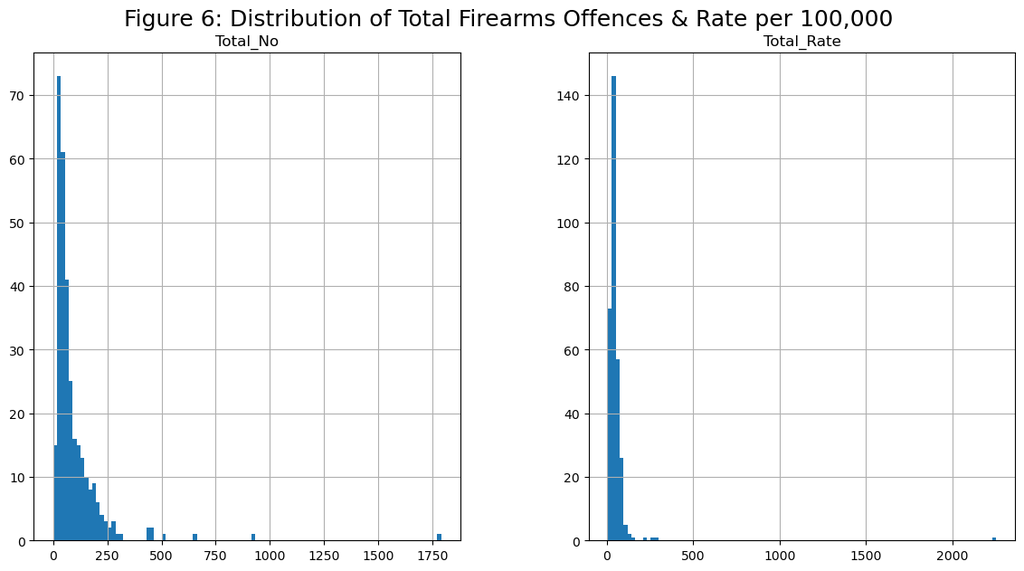

```python
# Create a histogram for both total number of firearms offences and total rate to check for
# outliers and visualise the distributions.

fig, axes = plt.subplots(1, 2)
claim2_pdf.hist('Total_No', bins=100, ax=axes[0])
claim2_pdf.hist('Total_Rate', bins=100, ax=axes[1])
plt.suptitle('Figure 6: Distribution of Total Firearms Offences & Rate per 100,000', fontsize=18, y=0.95)
plt.show()
```

```python
# Create a dataframe containing the top 25 CSPs with the highest total rate of firearms offences.
top_25 = claim2_pdf.sort_values(by='Total_Rate', ascending=False)
top_25 = top_25.head(25).round()
top_25
```

| CSP | 12/13_No | 12/13_Rate | 13/14_No | 13/14_Rate | 14/15_No | 14/15_Rate | 15/16_No | 15/16_Rate | 16/17_No | 16/17_Rate | 17/18_No | 17/18_Rate | Total_No | Total_Rate |
| --- | --- | --- | --- | --- | --- | --- | --- | --- | --- | --- | --- | --- | --- | --- |
| Uttlesford | 235 | 296.00 | 254 | 320.00 | 286 | 360.00 | 278 | 350.00 | 356 | 448.00 | 381 | 480.00 | 1790 | 2253.00 |
| Crawley | 5 | 5.00 | 13 | 12.00 | 60 | 56.00 | 154 | 144.00 | 38 | 36.00 | 45 | 42.00 | 315 | 296.00 |
| City of London | 2 | 27.00 | 3 | 41.00 | 2 | 27.00 | 1 | 14.00 | 4 | 54.00 | 7 | 95.00 | 19 | 258.00 |
| Westminster | 46 | 21.00 | 75 | 34.00 | 85 | 39.00 | 81 | 37.00 | 109 | 50.00 | 108 | 49.00 | 504 | 230.00 |
| Windsor and Maidenhead | 10 | 7.00 | 10 | 7.00 | 26 | 18.00 | 50 | 35.00 | 64 | 44.00 | 61 | 42.00 | 221 | 153.00 |
| Manchester | 63 | 13.00 | 69 | 14.00 | 85 | 17.00 | 103 | 20.00 | 117 | 23.00 | 222 | 44.00 | 659 | 131.00 |
| Salford | 54 | 23.00 | 33 | 14.00 | 35 | 15.00 | 50 | 21.00 | 44 | 19.00 | 80 | 34.00 | 296 | 127.00 |
| Boston | 8 | 12.00 | 12 | 19.00 | 11 | 17.00 | 13 | 20.00 | 16 | 25.00 | 11 | 17.00 | 71 | 110.00 |
| Luton | 18 | 9.00 | 30 | 15.00 | 39 | 19.00 | 30 | 15.00 | 42 | 21.00 | 48 | 24.00 | 207 | 102.00 |
| Knowsley | 15 | 10.00 | 26 | 18.00 | 25 | 17.00 | 29 | 20.00 | 27 | 19.00 | 26 | 18.00 | 148 | 101.00 |
| Liverpool | 62 | 13.00 | 69 | 15.00 | 88 | 19.00 | 79 | 17.00 | 66 | 14.00 | 94 | 20.00 | 458 | 98.00 |
| Slough | 22 | 16.00 | 20 | 14.00 | 23 | 16.00 | 25 | 18.00 | 19 | 14.00 | 28 | 20.00 | 137 | 98.00 |
| Hackney | 32 | 13.00 | 39 | 16.00 | 26 | 11.00 | 42 | 17.00 | 51 | 21.00 | 45 | 18.00 | 235 | 95.00 |
| Lambeth | 35 | 12.00 | 47 | 16.00 | 39 | 13.00 | 46 | 15.00 | 53 | 17.00 | 66 | 22.00 | 286 | 94.00 |
| Solihull | 22 | 11.00 | 28 | 14.00 | 44 | 21.00 | 27 | 13.00 | 31 | 15.00 | 35 | 17.00 | 187 | 90.00 |
| Newham | 38 | 12.00 | 37 | 12.00 | 28 | 9.00 | 64 | 21.00 | 48 | 16.00 | 60 | 19.00 | 275 | 89.00 |
| Tameside | 24 | 11.00 | 26 | 12.00 | 28 | 13.00 | 28 | 13.00 | 28 | 13.00 | 61 | 28.00 | 195 | 89.00 |
| Haringey | 31 | 12.00 | 23 | 9.00 | 17 | 7.00 | 42 | 16.00 | 45 | 18.00 | 65 | 25.00 | 223 | 87.00 |
| Nottingham | 40 | 13.00 | 43 | 14.00 | 40 | 13.00 | 55 | 18.00 | 43 | 14.00 | 46 | 15.00 | 267 | 87.00 |
| Bradford | 76 | 15.00 | 59 | 11.00 | 57 | 11.00 | 65 | 12.00 | 90 | 17.00 | 103 | 20.00 | 450 | 86.00 |
| Islington | 21 | 10.00 | 21 | 10.00 | 36 | 17.00 | 23 | 11.00 | 39 | 19.00 | 37 | 18.00 | 177 | 86.00 |
| Birmingham | 143 | 13.00 | 143 | 13.00 | 113 | 11.00 | 121 | 11.00 | 195 | 18.00 | 202 | 19.00 | 917 | 85.00 |
| Oldham | 29 | 13.00 | 35 | 16.00 | 26 | 12.00 | 23 | 10.00 | 20 | 9.00 | 59 | 26.00 | 192 | 85.00 |
| Lincoln | 7 | 7.00 | 10 | 11.00 | 7 | 7.00 | 13 | 14.00 | 17 | 18.00 | 24 | 26.00 | 78 | 83.00 |
| Leicester | 28 | 8.00 | 49 | 15.00 | 41 | 12.00 | 54 | 16.00 | 49 | 15.00 | 53 | 16.00 | 274 | 83.00 |

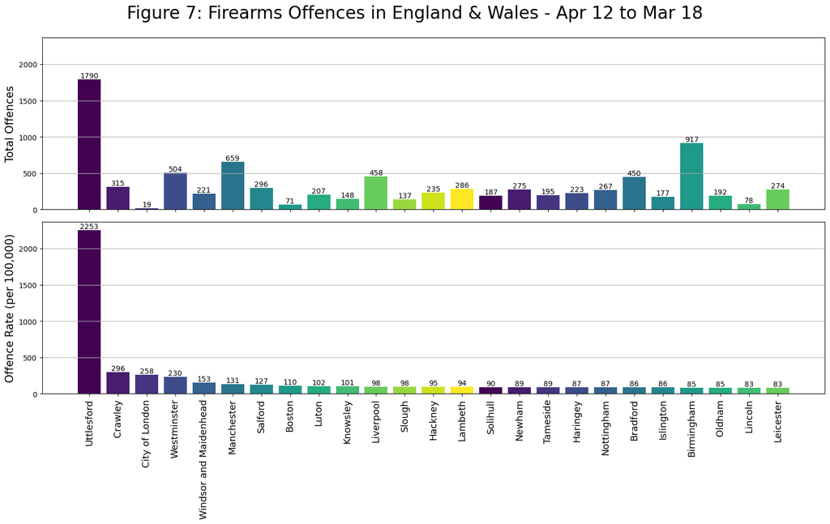

```python
# Create two bar charts to visualise the top 25 CSPs with the highest total rate of firearms
# offences. The first shows the total number and the second the total rate. Stack one on top of the
# other to enable comparison.

fig, axes = plt.subplots(nrows=2, ncols=1,
            sharex=True, sharey=True, figsize=(16, 10))

fig.suptitle('Figure 7: Firearms Offences in England & Wales - Apr 12 to Mar 18', fontsize=24, y=1)

ax_n = axes[0]
ax_r = axes[1]

cmap = plt.get_cmap('viridis')
colors = [cmap(i) for i in np.linspace(0, 1, len(top_25.columns))]

ax_n.bar(top_25.index, top_25.Total_No, color=colors)
ax_n.set_ylabel('Total Offences', fontsize=15)
ax_n.grid(axis = 'y')
ax_n.bar_label(ax_n.containers[0])

ax_r.bar(top_25.index, top_25.Total_Rate, color=colors)
ax_r.set_ylabel('Offence Rate (per 100,000)', fontsize=15)
ax_r.set_xticklabels(ax_r.get_xticks(), rotation=90)
ax_r.set_xticklabels(top_25.index, fontsize=13)
ax_r.grid(axis = 'y')
ax_r.bar_label(ax_r.containers[0])

fig.tight_layout()
plt.show()
```

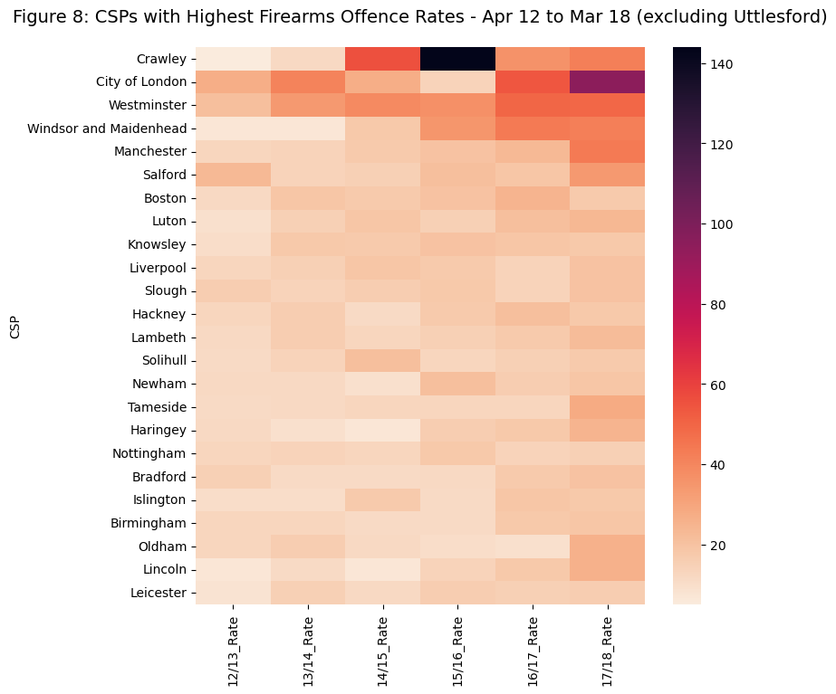

```python
# Check how the annual offence rate changes each year for the top 25 CSPs. First,
# filter out the number of offences columns and the 'Total_Rate' column. Then create
# a heatmap to visualise after removing the outlier 'Uttlesford'.

top_25_rate = top_25.drop(['12/13_No', '13/14_No', '14/15_No', '15/16_No',
                           '16/17_No', '17/18_No', 'Total_No', 'Total_Rate'], axis=1)
top_25_rate = top_25_rate.drop('Uttlesford')

plt.figure(figsize=(8, 8))

sns.heatmap(top_25_rate,cmap='rocket_r')
plt.xticks(rotation=90)
plt.title('Figure 8: CSPs with Highest Firearms Offence Rates - Apr 12 to Mar 18 (excluding Uttlesford)', fontsize=14, pad=20)
plt.show()
```

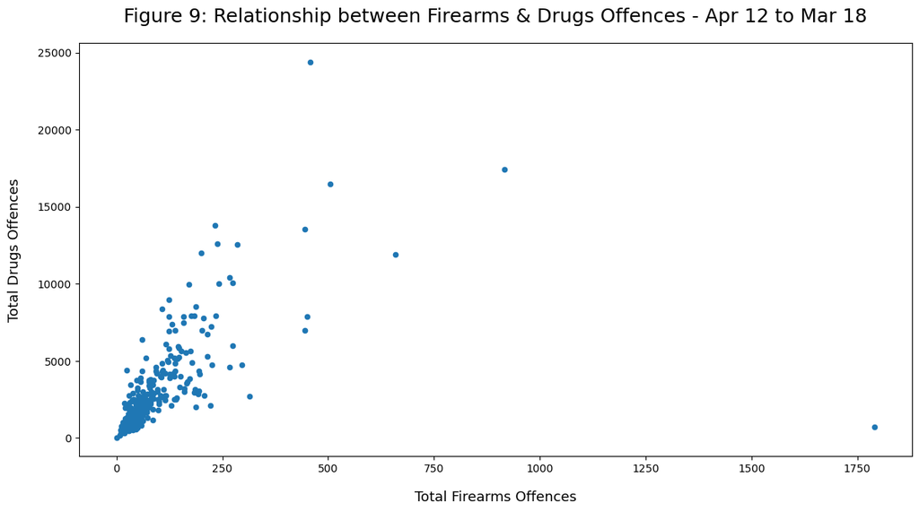

```python
# Start analysis of claim 3. First look at the relationship between total firearms offences and
# drugs offences for Apr 12 to Mar 18 using a scatter plot.

pivotPDF.plot.scatter(x = 'Total F', y = 'Total D', s = 20)
plt.title('Figure 9: Relationship between Firearms & Drugs Offences - Apr 12 to Mar 18', fontsize=18, pad=20)
plt.xlabel('Total Firearms Offences', fontsize=13, labelpad=15)
plt.ylabel('Total Drugs Offences', fontsize=13, labelpad=15)
plt.show()
```

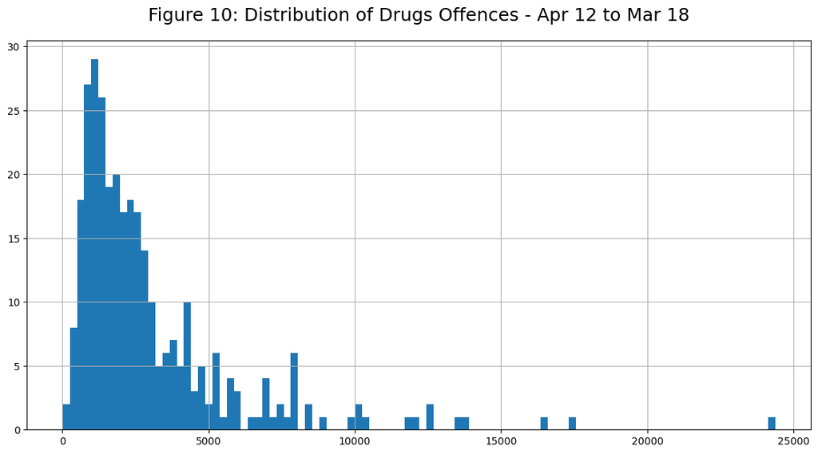

```python
# A histogram has already been created above for the total number of firearms offences during
# the analysis of claim 2. Do the same for drugs offences to check the shape of the distribution.

pivotPDF.hist(column='Total D', bins=100)
plt.title('Figure 10: Distribution of Drugs Offences - Apr 12 to Mar 18', fontsize=18, pad=20)
plt.show()
```

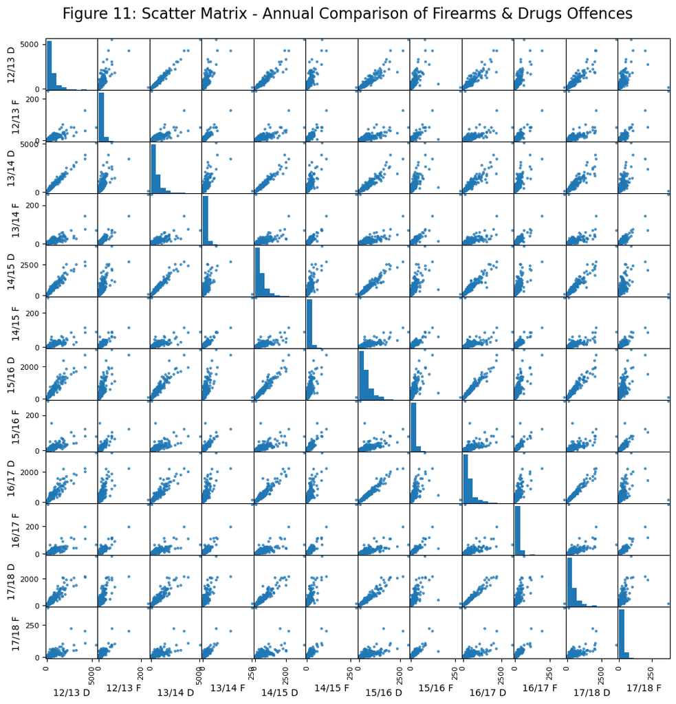

```python
# Use a scatter matrix to visual the relationship between firearms and drugs offences
# for each financial year, as well as check their distributions.

claim3_pdf = pivotPDF.drop(columns=['Total F', 'Total D', 'Population'])
scatter_matrix(claim3_pdf, alpha=0.8, figsize=(12, 12), diagonal='hist')
plt.suptitle('Figure 11: Scatter Matrix - Annual Comparison of Firearms & Drugs Offences', fontsize=16, y=0.92)
plt.show()
```

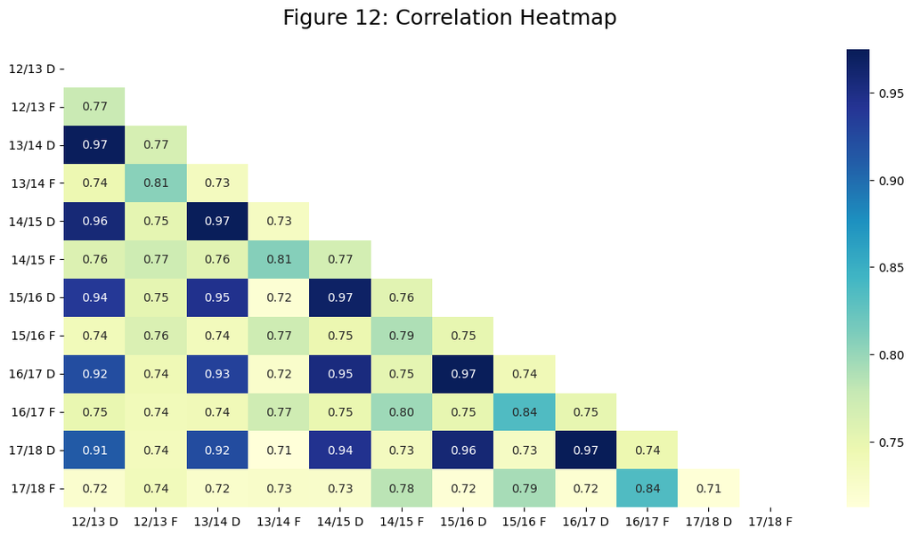

```python
# The data is not normally distributed, so use Spearman's rank correlation coefficient
# to quantify the strength of any relationship between the annual figures.

sp_coef = claim3_pdf.corr(method='spearman')
matrix = np.triu(sp_coef)
ax = sns.heatmap(sp_coef, annot=True, fmt=".2f", cmap="YlGnBu", mask=matrix)
plt.suptitle('Figure 12: Correlation Heatmap', fontsize=18, y=0.95, x=0.45)
plt.show()
```

```python
# Calculate the correlation coefficient for the whole time period from
# Apr 12 to Mar 18.

totals = pivotPDF.set_index('CSP')
totals = totals[["Total F", "Total D"]]
totals.corr(method='spearman')
```

|  | Total F | Total D |
| --- | --- | --- |
| Total F | 1.00 | 0.83 |
| Total D | 0.83 | 1.00 |

```python
# Remove 'Uttlesford' outlier to assess impact on overall level of correlation.

no_uf = totals.drop('Uttlesford')
no_uf.corr(method='spearman')
```

|  | Total F | Total D |
| --- | --- | --- |
| Total F | 1.00 | 0.85 |
| Total D | 0.85 | 1.00 |

The summary statistics clearly show the presence of one or more outliers in the firearms data. The max value for all variables is significantly higher than the mean and well beyond the range of the standard deviation. The histograms in figure 6 confirm the existence of at least one extreme value and show that the data is not normally distributed, but positively skewed.

The bar charts in figure 7 show that Uttlesford is the CSP area with the highest number and rate of firearm offences by some margin. When compared to the next highest CSP, the number of offences is almost double and the offence rate is around 8 times higher. These figures suggest there may be an error in the data, although this assumption appears to be incorrect. Stansted Airport is situated within the Uttlesford CSP area and was reported to have experienced a dramatic increase in offences during the period of the observations, which included possession of weapons offences [27]. Major airports are situated in or around some of the other CSPs with the highest offence rates, such as Crawley (Gatwick Airport), Windsor and Maidenhead (Heathrow Airport), Manchester, Luton and Liverpool. Despite this, their rates are much lower and it is unclear why Uttlesford and Stansted Airport are an outlier.

Turning to claim 3, the scatter plot in figure 9 indicates that firearms and drugs offences are positively correlated and have a linear relationship. This is also apparent in the scatter matrix in figure 11, which shows the relationship between the variables for each financial year. The consistency of the relationship from year-to-year suggests that the correlation is not significantly influenced by another variable.

Neither variable follows a normal distribution, as shown in the histograms in figures 6 and 10. Consequently, the Spearman rank correlation coefficient was used to quantify the strength of the correlation. Figure 12 shows that the coefficient each financial year between April 2012 and March 2018 was 0.77, 0.73, 0.77, 0.75, 0.75 and 0.71 respectively. The tables above also show the coefficient for the whole period; this is 0.83 with the Uttlesford CSP and 0.85 without this outlier. These values demonstrate a high positive correlation between firearms and drugs offences [28].

## 7. Critical Analysis of Methodology

The analysis of claim 1 involved the use of SARIMA and HWES time series forecasting models. One major benefit of SARIMA is that it delivers "near state-of-the-art performance, particularly in cases of small data sets" [18]. In this study, it was relatively easy to implement and produced a model which fits the data quite well. However, selecting the right parameters to solve the optimisation problem is not easy and the grid search method used is considered a brutish approach [29]. Other studies have employed more complex methods such as genetic algorithms and performed well [30]. As such, the SARIMA model could have achieved better results in this case if a different method was adopted, especially since the HWES model performed better without tuning.

Exponential smoothing methods like HWES often achieve good results [31] and are relatively simple to use, as demonstrated above. They work well when the data moves slowly over time [32] and the weight they place on recent data means they are adept at short-term forecasting [33]. Unsurprisingly, this means they are less proficient when forecasting over longer periods, unlike SARIMA which has been shown to be better in these circumstances [17].

Time series methods in general require a large amount of historical data [34], which was not available in this case. This was not an issue as only short-term forecasts were made and the data used was able to achieve credible results. If longer-term forecasts were required then more data would have been needed, ideally several decades worth in order to capture previous cyclical fluctuations. As noted above, the predicted values for both models seemed to continue on an upward trend toward the end of the 24-month forecast when the observed values started to plateau. Therefore, more data may have made the models better at forecasting this change in the observations, particularly SARIMA.

Nevertheless, more data doesn't necessarily mean better predictions as external events may also need to be considered. If so, the SARIMAX method could be a better approach as it uses exogenous variables to represent external factors which might influence the data. For example, public spending on policing and law enforcement is one variable which could affect the rate of violent crime. However, choosing exogenous variables requires domain knowledge and they also need to be forecasted, which can exacerbate the error if long-term predictions are made [35]. Moreover, not all external events can be foreseen, as was the case with the COVID-19 pandemic in 2020.

The use of population data was necessary to calculate the rate of firearms crimes during the analysis of claim 2. This data was taken from the file 'LSOA_pop_v2.csv', which provided the population for each LSOA that was recorded in 2011. Although it subsequently enabled the comparison of crime rates across CSPs for a claim made in 2018, it is important to be cautious when interpreting the results as populations change over time. Similarly, Oliveira [36, p.9] states that "crime often increases with population size at a different pace than per capita", even though linearity is assumed in most cases. He notes this assumption can influence the rankings of cities based on per capita crime rates and advises caution when making comparisons.

The heatmap in figure 8 highlights how the firearms offence rates changed in the highest-ranked CSPs each year. Uttlesford was deliberately excluded from this visualisation as its inclusion would have resulted in the remaining CSPs becoming indistinguishable due to its own strong colouring. This shows that heatmaps can be rendered meaningless if the data behind them contains extreme values.

Correlation was used to assess claim 3 and determine the strength of the relationship between firearms and drugs offences. When using this technique, Aggarwal and Ranganathan [37] warn that outliers and small sample sizes can indicate a relationship between two variables when none exists. The former was negated in this study by calculating the correlation coefficient twice to check whether the outlier Uttlesford significantly influenced the statistic, which it did not. The use of big data means sample size was not an issue, however volume does not necessarily eliminate errors as large datasets can also lead to spurious correlations [38].

It is also important to comment on the data used to analyse the three claims. The UK's ONS previously cast doubt on the reliability of police-recorded crime data in 2014 [39]. This appears to be an ongoing issue as Greater Manchester Police have failed to record a large number of crimes in recent years, with 80,000 being missed between July 2019 and June 2020 [40]. The ONS have also stated that the figures for some crimes like drug possession offences are "heavily influenced by police activities and priorities", meaning they "may not provide an accurate picture of the true extent of criminality" [41]. Additionally, the CSP data used in this study does not always include every crime recorded by a police service, as some occur in areas that do not have a designated CSP and are therefore classified as 'unassigned'. Given these points, the results of any analysis based on UK crime data should be carefully considered.

## 8. Conclusion

The main aim of this project was to assess the validity of the 3 claims made in the documentary “Ross Kemp and the Armed Police” at the time it was broadcast in September 2018. The first claim stated that violent crime was increasing and time series analysis shows there was an upward trend in these offences from mid-2013 to the time of the broadcast. Therefore, it would be correct to say that violent crime in England and Wales **had been** increasing at the time of the broadcast, but this cannot be inferred for the whole UK without further statistical analysis.

If time series forecasting had been conducted at the time to predict whether the number of violent crimes **would continue** to increase, the analysis would have indicated they would. However, the observed values show that these offences started to plateau after the broadcast, meaning the forecasts may have been misleading and led to false claims, particularly if long-term predictions were made. This shows that time series forecasting is not infallible, especially when historical data is limited or unforeseen external events occur.

The data used in the study dictated that the CSP geographical area be used as the basis for comparison when analysing claim 2. It is therefore possible that Birmingham could have had the highest rate if different geography was used, such as the 'built up conglomerations and built up areas' UK census classification that incorporates villages, towns and cities [42]. Nonetheless, even when comparing the city Birmingham to other cities, this study has shown that the City of London, Manchester, Liverpool and Nottingham all had higher rates. As a result, the second claim can be rejected with some confidence as there are other cities in the UK with higher rates of firearms incidents.

Lastly, the third claim stated that crimes involving firearms were closely associated with drugs offences. Again, the period from April 2012 to March 2018 was selected for analysis and correlation was used to assess the relationship between the two variables. The results show that the offences had a high positive correlation over the whole time period and this relationship was consistent from year-to-year. The level of consistency indicates that the relationship isn't overly influenced by other factors like geographical area and the strong correlation between the offences is also evidenced by the National Crime Agency, which has a national remit. Consequently, firearms and drugs offences in England and Wales are closely associated and this is highly likely to be the case across the UK, therefore claim 3 is valid.

## 9. References

[1] A. Gorelik, *The Enterprise Big Data Lake: Delivering the Promise of Big Data and Data Science*. Sebastopol, CA, U.S.: O′Reilly, 2019. [Online]. Available: https://learning.oreilly.com/library/view/the-enterprise-big/9781491931547/

[2] R. Kumar and B. Nagpal, "Analysis and prediction of crime patterns using big data", *International Journal of Information Technology*, vol. 11, pp.799–805, Dec. 2018. [Online]. Available: https://doi.org/10.1007/s41870-018-0260-7

[3] N. Dasgupta, *Practical Big Data Analytics: Hands-on Techniques to Implement Enterprise Analytics and Machine Learning Using Hadoop, Spark, NoSQL and R*. Birmingham, UK: Packt, 2018. [Online]. Available: https://learning.oreilly.com/library/view/practical-big-data/9781783554393/

[4] A. LaPlante, *The Big Data Transformation: Understanding Why Change Is Actually Good for Your Business*. Sebastopol, CA, U.S.: O′Reilly, 2017. [Online]. Available: https://learning.oreilly.com/library/view/the-big-data/9781492049012/

[5] House of Commons Library, *Firearm Crime Statistics: England & Wales*. Aug. 2022. [Online]. Available: https://commonslibrary.parliament.uk/research-briefings/cbp-7654/

[6] Home Office, "Police recorded crime and outcomes open data tables: Police recorded crime and outcomes detailed figures and supplementary material including a user guide." Official Statistics. https://www.gov.uk/government/statistics/police-recorded-crime-open-data-tables (Accessed: September 23, 2023).

[7] Office for National Statistics, "Open Geography Portal". Office for National Statistics. https://geoportal.statistics.gov.uk/ (Accessed: September 23, 2023).

[8] J.S. Damji, B. Wenig, T. Das, and D. Lee, *Learning Spark: Lightning-Fast Data Analytics*, 2nd ed. Sebastopol, CA, U.S.: O′Reilly, 2020. [Online]. Available: https://learning.oreilly.com/library/view/learning-spark-2nd/9781492050032/

[9] A. Anderson and D. Semmelroth, *Statistics for Big Data For Dummies*. Hoboken, New Jersey: John Wiley & Sons, Inc., 2015. [Online]. Available: https://learning.oreilly.com/library/view/statistics-for-big/9781118940013/

[10] E. Baumer, "Crime Trends", in *The Oxford Handbook of Crime and Criminal Justice*. M. Tonry, Ed. New York, U.S.: Oxford University Press, 2011, pp.26–59. [Online]. Available: https://doi.org/10.1093/oxfordhb/9780195395082.013.0002

[11] M.A. Andresen and N. Malleson, "Crime seasonality and its variations across space", *Applied Geography*, vol. 43, pp.25-35, Sep. 2013. [Online]. Available: https://doi.org/10.1016/j.apgeog.2013.06.007

[12] T.A. Atwan, *Time Series Analysis with Python Cookbook: Practical Recipes for Exploratory Data Analysis, Data Preparation, Forecasting, and Model Evaluation*. Birmingham, UK: Packt, 2022. [Online]. Available: https://learning.oreilly.com/library/view/time-series-analysis/9781801075541/

[13] N. Shiode, S. Shiode, H. Nishi and K. Hino, "Seasonal characteristics of crime: an empirical investigation of the temporal fluctuation of the different types of crime in London", *Computational Urban Science*, vol. 3, no. 19, May 2023. [Online]. Available: https://doi.org/10.1007/s43762-023-00094-x

[14] S.R. Anuvarshini, Deeksha Nidhi, Deeksha Sree C, and Krishna Sowjanya K, "Crime Forecasting : A Theoretical Approach", in *2022 IEEE 7th International Conference on Recent Advances and Innovations in Engineering (ICRAIE)*, Mangalore, India, 2022, pp.37-41. [Online]. Available: https://doi.org/10.1109/ICRAIE56454.2022.10054345

[15] P. Chen, H. Yuan and X. Shu, "Forecasting Crime Using the ARIMA Model", in *2008 Fifth International Conference on Fuzzy Systems and Knowledge Discovery*, Jinan, China, 2008, pp.627-630. [Online]. Available: https://doi.org/10.1109/FSKD.2008.222

[16] W. Gorr, A. Olligschlaeger and Y. Thompson, "Short-term forecasting of crime", *International Journal of Forecasting*, vol. 19, issue no. 4, pp.579-594, Oct. to Dec. 2003. [Online]. Available: https://doi.org/10.1016/S0169-2070(03)00092-X

[17] G.R.A. Brito, A.R. Villaverde, A.L. Quan and M.E.R. Pérez. "Comparison between SARIMA and Holt–Winters models for forecasting monthly streamflow in the western region of Cuba", *SN Applied Sciences*, vol. 3, no. 671, May. 2021. [Online]. Available: https://doi.org/10.1007/s42452-021-04667-5

[18] A. Nielsen, *Practical Time Series Analysis: Prediction with Statistics and Machine Learning*. Sebastopol, CA, U.S.: O′Reilly, 2019. [Online]. Available: https://learning.oreilly.com/library/view/practical-time-series/9781492041641/

[19] M. Joseph, *Modern Time Series Forecasting with Python: Explore industry-ready time series forecasting using modern machine learning and deep learning*. Birmingham, UK: Packt, 2022. [Online]. Available: https://learning.oreilly.com/library/view/modern-time-series/9781803246802/

[20] M. Swamynathan, *Mastering Machine Learning with Python in Six Steps: A Practical Implementation Guide to Predictive Data Analytics Using Python*. Bangalore, Karnataka, India: Apress, 2017. [Online]. Available: https://learning.oreilly.com/library/view/mastering-machine-learning/9781484228661/

[21] P. Goodwin, *Profit From Your Forecasting Software: A Best Practice Guide for Sales Forecasters*. Hoboken, New Jersey: John Wiley & Sons, Inc., 2018. [Online]. Available: https://learning.oreilly.com/library/view/profit-from-your/9781119414575/

[22] J. Korstanje, *Advanced Forecasting with Python: With State-of-the-Art-Models Including LSTMs, Facebook’s Prophet, and Amazon’s DeepAR*. New York, U.S.: Apress, 2021. [Online]. Available: https://doi.org/10.1007/978-1-4842-7150-6

[23] C.O. Wilke, *Fundamentals of Data Visualization: A Primer on Making Informative and Compelling Figures*. Sebastopol, CA, U.S.: O′Reilly, 2019. [Online]. Available: https://learning.oreilly.com/library/view/fundamentals-of-data/9781492031079/

[24] L. Baker, *Associations and Correlations: Unearth the powerful insights buried in your data*. Birmingham, UK: Packt, 2022. [Online]. Available: https://learning.oreilly.com/library/view/associations-and-correlations/9781838980412/

[25] F. Juretig, *R Statistics Cookbook: Over 100 recipes for performing complex statistical operations with R 3.5*. Birmingham, UK: Packt, 2019. [Online]. Available: https://learning.oreilly.com/library/view/r-statistics-cookbook/9781789802566/

[26] National Crime Agency, *National Strategic Assessment of Serious and Organised Crime 2020*. 2020. [Online]. Available: https://www.nationalcrimeagency.gov.uk/news/nsa2020

[27] BBC, "Crime at airports has doubled in two years". News. https://www.bbc.co.uk/news/uk-england-45059001 (Accessed: September 23, 2023).

[28] M.M. Mukaka, "A guide to appropriate use of Correlation coefficient in medical research", *Malawi Medical Journal*, vol. 24, no. 3, pp.69–71, Sep. 2012. [Online]. Available: https://www.ncbi.nlm.nih.gov/pmc/articles/PMC3576830/#:~:text=A%20correlation%20coefficient%20of%20zero,between%20%E2%88%921%20and%20%2B1.

[29] A. Géron, *Hands-On Machine Learning with Scikit-Learn, Keras, and TensorFlow: Concepts, Tools, and Techniques to Build Intelligent Systems*, 3rd ed. Sebastopol, CA, U.S.: O′Reilly, 2023. [Online]. Available: https://learning.oreilly.com/library/view/hands-on-machine-learning/9781098125967/

[30] M. Farsi *et al*, "Parallel genetic algorithms for optimizing the SARIMA model for better forecasting of the NCDC weather data", *Alexandria Engineering Journal*, vol. 60, issue no. 1, pp.1299-1316, Feb. 2021. [Online]. Available: https://doi.org/10.1016/j.aej.2020.10.052

[31] R. Fried and A.C. George, "Exponential and Holt-Winters Smoothing", in *International Encyclopedia of Statistical Science*. M. Lovric, Ed. Berlin, Heidelberg: Springer, 2011, pp.488–490. [Online]. Available: https://doi.org/10.1007/978-3-642-04898-2_244

[32] B.V. Vishwas and A. Patel, *Hands-on Time Series Analysis with Python: From Basics to Bleeding Edge Techniques*. New York, U.S.: Apress, 2020. [Online]. Available: https://doi.org/10.1007/978-1-4842-5992-4

[33] Simplilearn, "An Introduction to Exponential Smoothing for Time Series Forecasting in Python", Simplilearn. https://www.simplilearn.com/exponential-smoothing-for-time-series-forecasting-in-python-article#:~:text=An%20exponential%20smoothing%20method%20can,the%20squared%20errors%20(SSE). (Accessed: September 23, 2023).

[34] C.W. Chase Jr., *Demand-Driven Forecasting: A Structured Approach to Forecasting*, 2nd Ed. Hoboken, New Jersey: John Wiley & Sons, Inc., 2013. [Online]. Available: https://learning.oreilly.com/library/view/demand-driven-forecasting-a/9781118735572/

[35] M. Peixeiro, *Time Series Forecasting in Python*. Shelter Island, NY: Manning, 2022. [Online]. Available: https://learning.oreilly.com/library/view/time-series-forecasting/9781617299889/

[36] M. Oliveira, "More crime in cities? On the scaling laws of crime and the inadequacy of per capita rankings—a cross-country study", *Crime Science*, vol. 10, no. 27, Dec. 2021. [Online]. Available: https://doi.org/10.1186/s40163-021-00155-8

[37] R. Aggarwal and P. Ranganathan, "Common pitfalls in statistical analysis: The use of correlation techniques", *Perspectives in Clinical Research*, vol. 7, no. 4, pp.187–190, Oct. to Dec. 2016. [Online]. Available: https://doi.org/10.4103/2229-3485.192046

[38] C.S. Calude and G. Longo, "The Deluge of Spurious Correlations in Big Data", *Foundations of Science*, vol. 22, pp.595–612, Sep. 2017. [Online]. Available: https://doi.org/10.1007/s10699-016-9489-4

[39] UK Statistics Authority, *Assessment of compliance with the Code of Practice for Official Statistics: Statistics on Crime in England and Wales (produced by the Office for National Statistics) - Assessment Report 268*. Jan. 2014. [Online]. Available: https://uksa.statisticsauthority.gov.uk/wp-content/uploads/2015/12/images-assessmentreport268statisticsoncrimeinenglandandwale_tcm97-43508-1.pdf

[40] BBC, "Greater Manchester Police review finds 1,600 more unrecorded crimes". News. https://www.bbc.co.uk/news/uk-england-manchester-56676907 (Accessed: September 23, 2023).

[41] Office for National Statistics, "User guide to crime statistics for England and Wales: March 2023". Office for National Statistics. https://www.ons.gov.uk/peoplepopulationandcommunity/crimeandjustice/methodologies/userguidetocrimestatisticsforenglandandwales (Accessed: September 23, 2023).

[42] Office for National Statistics,"Census 2021 geographies: Guidance about the different geographies used for the results of Census 2021, for analysts and researchers using census data". Office for National Statistics. https://www.ons.gov.uk/methodology/geography/ukgeographies/censusgeographies/census2021geographies (Accessed: September 24, 2023).

Return to top of report